# Analiza skupa podataka o svetlosnom zračenju na području Tajvana

### Logistička regresija

Podešavani hiperparametri:

- **reg_parameter - regularizacioni parametar (lambda)**
  - poznat i kao kazneni član, pomaže u sprečavanju pretreniranja dodavanjem kazne za veće koeficijente.
    - 0 - bez regularizacije
    - 0.001 - mala kolicina regularizacije
    - 0.1 - umerena regularizacija
- **max_iterations - maksimalni broj iteracija algoritma**
  - 100 - podrazumevan broj
  - 500 - povećan broj iteracija
  - 1000 - velik broj iteracija

```r
start_time <- proc.time()

reg_parameter <- c(0, 0.001, 0.1)
max_iterations <- c(100, 500, 1000)

accuracies <- numeric(3)
sensitivities <- numeric(3)
specificities <- numeric(3)

for(scenario in 1:3){
  accuracy_sum <- 0
  sensitivity_sum <- 0
  specificity_sum <- 0

  for(i in 1:k_folds){
    paritioned_data <- split_data(df_spark, i, fold_size)

    logreg <- ml_logistic_regression(paritioned_data$train_set,
                                     formula,
                                     reg_param = reg_parameter[scenario],
                                     max_iter = max_iterations[scenario],
                                     family = "binomial")

    performance <- calc_perf(logreg, paritioned_data$test_set)

    accuracy_sum <- accuracy_sum + performance[["accuracy"]]
    sensitivity_sum <- sensitivity_sum + performance[["sensitivty"]]
    specificity_sum <- specificity_sum + performance[["specificity"]]
  }

  accuracies[scenario] <- accuracy_sum / k_folds
  sensitivities[scenario] <- sensitivity_sum / k_folds
  specificities[scenario] <- specificity_sum / k_folds
}

# Prikaz rezultata
results_logreg <- data.frame(accuracies,
                      sensitivities,
                      specificities)

rownames(results_logreg) <- c("Scenario 1", "Scenario 2", "Scenario 3")
colnames(results_logreg) <- c("Accuracy", "Sensitivity", "Specificity")

knitr::kable(results_logreg,
             label = "Prikaz rezultata logisticke regresije",
             format = "html"
) %>%
  kableExtra::kable_styling(bootstrap_options = "bordered", full_width = FALSE, font_size = 16)
end_time <- proc.time()
elapsed = end_time-start_time
print(paste("Elapsed time:",round(elapsed[3] / 60,2)))
```

[output not shown]

Podešavani hiperparametri:

- **reg_parameter - regularizacioni parametar (lambda)**
  - poznat i kao kazneni član, pomaže u sprečavanju pretreniranja dodavanjem kazne za veće koeficijente.
    - 0 - bez regularizacije
    - 0.001 - mala kolicina regularizacije
    - 0.1 - umerena regularizacija
- **max_iterations - maksimalni broj iteracija algoritma**
  - 100 - podrazumevan broj
  - 500 - povećan broj iteracija
  - 1000 - velik broj iteracija

```r
start_time <- proc.time()
#### Obucanvanje i validacija
reg_parameter <- c(0, 0.001, 0.1)
max_iterations <- c(100, 500, 1000)

accuracies <- numeric(3)
sensitivities <- numeric(3)
specificities <- numeric(3)

for(scenario in 1:3){
  accuracy_sum <- 0
  sensitivity_sum <- 0
  specificity_sum <- 0

  for(i in 1:k_folds){
    paritioned_data <- split_data(df_spark, i, fold_size)

    lsvc <- ml_logistic_regression(paritioned_data$train_set,
                                     formula,
                                     reg_param = reg_parameter[scenario],
                                     max_iter = max_iterations[scenario])

    performance <- calc_perf(lsvc, paritioned_data$test_set)

    accuracy_sum <- accuracy_sum + performance[["accuracy"]]
    sensitivity_sum <- sensitivity_sum + performance[["sensitivty"]]
    specificity_sum <- specificity_sum + performance[["specificity"]]
  }

  accuracies[scenario] <- accuracy_sum / k_folds
  sensitivities[scenario] <- sensitivity_sum / k_folds
  specificities[scenario] <- specificity_sum / k_folds
}

# Prikaz rezultata
results_lsvc <- data.frame(accuracies,
                      sensitivities,
                      specificities)

rownames(results_lsvc) <- c("Scenario 1", "Scenario 2", "Scenario 3")
colnames(results_lsvc) <- c("Accuracy", "Sensitivity", "Specificity")

knitr::kable(results_lsvc,
             label = "Prikaz rezultata lsvc",
             format = "html"
) %>%
  kableExtra::kable_styling(bootstrap_options = "bordered", full_width = FALSE, font_size = 16)
end_time <- proc.time()
elapsed = end_time-start_time
print(paste("Elapsed time:",round(elapsed[3] / 60,2)))
```

[output not shown]

#### Odnosi hiperparametara i performansi

### Stablo odlučivanja

- **max_depth - maksimalna dubina stabla**
  - Određuje maksimalnu dubinu pojedinačnog stabla. Dublje drveće može uhvatiti složenije obrasce u podacima, ali su takođe sklonija preobučavanju.
    - 5 - umerena dubina
    - 10 - dublje drveće
    - 20 - vrlo duboko drveće
- **min_instances_per_node - minimalan broj instanci po čvoru**
  - Definiše minimalan broj instanci koji se moraju nalaziti u čvoru stabla pre nego što se on može podeliti na dva deteta. Veća vrednost može sprečiti preobučavanje forsiranjem modela da razmotri više podataka prilikom deljenja čvorova.
  - Vrijednosti za probno podešavanje -
    - 2 - niska vrednost
    - 5 - umerena vrednost
    - 10 - visoka vrednost

```r
start_time <- proc.time()
#### Obucanvanje i validacija
max_depth <- c(5,10,20)
min_instances_per_node <- c(2,5,10)

accuracies <- numeric(3)
sensitivities <- numeric(3)
specificities <- numeric(3)

for(scenario in 1:3){

  accuracy_sum <- 0
  sensitivity_sum <- 0
  specificity_sum <- 0

  for(i in 1:k_folds){
    paritioned_data <- split_data(df_spark, i, fold_size)

    dt <- ml_decision_tree_classifier(paritioned_data$train_set,
                                  formula,
                                  max_depth = max_depth[scenario],
                                  min_instances_per_node = min_instances_per_node[scenario]
    )

    performance <- calc_perf(dt, paritioned_data$test_set)

    accuracy_sum <- accuracy_sum + performance[["accuracy"]]
    sensitivity_sum <- sensitivity_sum + performance[["sensitivty"]]
    specificity_sum <- specificity_sum + performance[["specificity"]]
  }

  accuracies[scenario] <- accuracy_sum / k_folds
  sensitivities[scenario] <- sensitivity_sum / k_folds
  specificities[scenario] <- specificity_sum / k_folds
}

# Prikaz rezultata
results_dt <- data.frame(accuracies,
                      sensitivities,
                      specificities)

rownames(results_dt) <- c("Scenario 1", "Scenario 2", "Scenario 3")
colnames(results_dt) <- c("Accuracy", "Sensitivity", "Specificity")

knitr::kable(results_dt,
             label = "Prikaz rezultata stabla odlucivanja",
             format = "html"
) %>%
  kableExtra::kable_styling(bootstrap_options = "bordered", full_width = FALSE, font_size = 16)
end_time <- proc.time()
elapsed = end_time-start_time
print(paste("Elapsed time:",round(elapsed[3] / 60,2)))
```

[output not shown]

#### Odnosi hiperparametara i performansi

## Klasterizacija

### Normalizacija podataka

```r
df_spark_normalized <- copy_to(sc, df_shuffled, "df_spark_normalized", overwrite = TRUE)
df_spark_normalized %<>%
  mutate(time_numeric = as.numeric(time))


features <- c("air_temp", "wind_speed", "time_numeric", "longitude", "latitude")

means <- numeric(length(features))
stds <- numeric(length(features))

names(means) <- features
names(stds) <- features

for(col in features){
  summary_stats <- df_spark_normalized %>%
    summarise(
      mean_value = mean(!!sym(col), na.rm = TRUE),
      std_value = sd(!!sym(col), na.rm = TRUE)
    ) %>%
    collect()

  means[col] <- summary_stats$mean_value
  stds[col] <- summary_stats$std_value
}


for (col in features) {
  mean <- means[col]
  std <- stds[col]

  df_spark_normalized <- df_spark_normalized %>%
    mutate(!!sym(col) := (!!sym(col) - mean) / std)
}
```

### Crtanje Elbow plota

Crtamo elbow plot kako bi odredili najpogodnije k za klasterizaciju

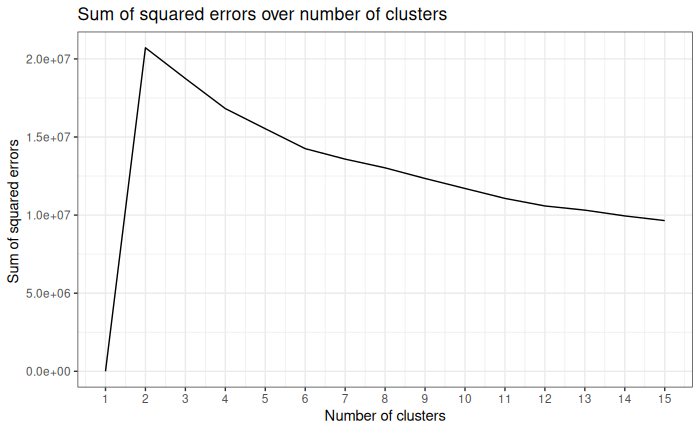

```r
start_time <- proc.time()

formula_clustering <- ghi_c ~ air_temp + wind_speed + time_numeric + longitude + latitude
sum_of_squared_errors <- numeric(15)
for(k in 2:15){
  clustered <- ml_bisecting_kmeans(df_spark_normalized, formula = formula_clustering, k = k)
  sum_of_squared_errors[k] <- clustered$cost
}


# Prikaz

k_errors_df <- data.frame(1:15, sum_of_squared_errors)
colnames(k_errors_df) <- c("K", "sum_of_squared_errors")


# Create the ggplot object
k_elbow_plot <- ggplot(k_errors_df) +
  geom_line(mapping = aes(x = K, y = sum_of_squared_errors)) +
  labs(title = "Sum of squared errors over number of clusters",
       x = "Number of clusters",
       y = "Sum of squared errors ") +
  theme_bw() +
  scale_x_continuous(breaks = seq(1, 15, by = 1))  # Set breaks from 1 to 15 with a step of 1
k_elbow_plot


end_time <- proc.time()
elapsed = end_time-start_time
print(paste("Elapsed time:",round(elapsed[3] / 60,2)))
```

Klasterizacija prema 2 scenarija:

- **k = 6**
- **k = 12**

Izabran je Bisecting KMeans jer:

- Ne podrazumeva sfericne klastere
- Nema problema sa zaglavljivanjem u lokalnom optimumu

```r
  cluster_k_6 <- ml_bisecting_kmeans(df_spark_normalized, formula = formula_clustering, k = 6)
  cluster_k_12 <- ml_bisecting_kmeans(df_spark_normalized, formula = formula_clustering, k = 12)
```

### Ispitivanje strukture dobijenih klastera

```r
cluster_k_6
cluster_k_12
```

```r
predicted_clusters_6 <- ml_predict(cluster_k_6, df_spark_normalized)
predicted_clusters_6 %<>%
  select(prediction) %>%
  rename("cluster_6" = prediction)

predicted_clusters_12 <- ml_predict(cluster_k_12, df_spark_normalized)
predicted_clusters_12 %<>%
  select(prediction) %>%
  rename("cluster_12" = prediction)


df_spark <- sdf_bind_cols(df_spark,predicted_clusters_6, predicted_clusters_12)
```

### Vizualizacija odnosa izmedju vrednosti obelezja i pripadnosti klasteru

#### k = 6

```r
long_lat_clust_6 <- ggplot(df_spark, aes(x = longitude, y = latitude, color = cluster_6)) +
  geom_point() +
  labs(title = "Scatter Plot with Cluster Colors",
       x = "Longitude",
       y = "Latitude")
long_lat_clust_6
```

[output not shown]

## Zatvaranje spark konekcije

```r
spark_disconnect(sc)
```